# CS236781: Deep Learning on Computational Accelerators

### Generating text by sampling

Now that we have a model, we can implement **text generation** based on it. The idea is simple: At each timestep our model receives one char $x_t$ from the input sequence and outputs scores $y_t$ for what the next char should be. We'll convert these scores into a probability over each of the possible chars. In other words, for each input char $x_t$ we create a probability distribution for the next char conditioned on the current one and the state of the model (representing all previous inputs): $$p(x_{t+1}|x_t, \vec{h}_t).$$

Once we have such a distribution, we'll sample a char from it. This will be the first char of our generated sequence. Now we can feed this new char into the model, create another distribution, sample the next char and so on. Note that it's crucial to propagate the hidden state when sampling.

The important point however is how to create the distribution from the scores. One way, as we saw in previous ML tasks, is to use the softmax function. However, a drawback of softmax is that it can generate very diffuse (more uniform) distributions if the score values are very similar. When sampling, we would prefer to control the distributions and make them less uniform to increase the chance of sampling the char(s) with the highest scores compared to the others.

To control the variance of the distribution, a common trick is to add a hyperparameter $T$, known as the *temperature* to the softmax function. The class scores are simply scaled by $T$ before softmax is applied: $$ \mathrm{softmax}_T(\vec{y}) = \frac{e^{\vec{y}/T}}{\sum_k e^{y_k/T}} $$

A low $T$ will result in less uniform distributions and vice-versa.

**TODO**: Implement the `hot_softmax()` function in the `hw3/charnn.py` module.

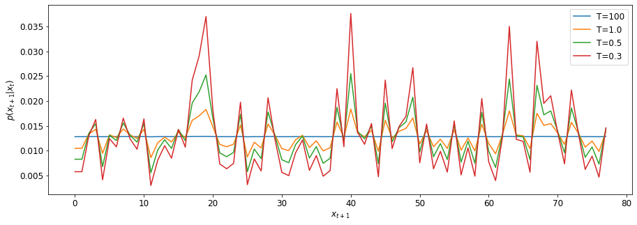

```python
scores = y[0,0,:].detach()
_, ax = plt.subplots(figsize=(15,5))

for t in reversed([0.3, 0.5, 1.0, 100]):
    ax.plot(charnn.hot_softmax(scores, temperature=t).cpu().numpy(), label=f'T={t}')
ax.set_xlabel('$x_{t+1}$')
ax.set_ylabel('$p(x_{t+1}|x_t)$')
ax.legend()

uniform_proba = 1/len(char_to_idx)
uniform_diff = torch.abs(charnn.hot_softmax(scores, temperature=100) - uniform_proba)
test.assertTrue(torch.all(uniform_diff < 1e-4))
```

**TODO**: Implement the `generate_from_model()` function in the `hw3/charnn.py` module.

```python
for _ in range(3):
    text = charnn.generate_from_model(model, "foobar", 50, (char_to_idx, idx_to_char), T=0.5)
    print(text)
    test.assertEqual(len(text), 50)
```

```
foobarYQAmsdup.))(t,I94Fv4ZpTh)cZ7zgZr7-z.atqix3
q
foobarkVuQ(Zdzv6Zk9vZkIs2IsszpF:W]V,hVlZR(7r8'!S8.
foobar8Vp!&RKVJT7QAq876SuE89Lv-.]SFqQupvN9EQ8VVJxl
```

### Training

To train this model, we'll calculate the loss at each time step by comparing the predicted char to the actual char from our label. We can use cross entropy since per char it's similar to a classification problem. We'll then sum the losses over the sequence and back-propagate the gradients though time. Notice that the back-propagation algorithm will "visit" each layer's parameter tensors multiple times, so we'll accumulate gradients in parameters of the blocks. Luckily `autograd` will handle this part for us.

As usual, the first step of training will be to try and **overfit** a large model (many parameters) to a tiny dataset. Again, this is to ensure the model and training code are implemented correctly, i.e. that the model can learn.

For a generative model such as this, overfitting is slightly trickier than for classification. What we'll aim to do is to get our model to **memorize** a specific sequence of chars, so that when given the first char in the sequence it will immediately spit out the rest of the sequence verbatim.

Let's create a tiny dataset to memorize.

```python
# Pick a tiny subset of the dataset
subset_start, subset_end = 1001, 1005
ds_corpus_ss = torch.utils.data.Subset(ds_corpus, range(subset_start, subset_end))
batch_size_ss = 1
sampler_ss = SequenceBatchSampler(ds_corpus_ss, batch_size=batch_size_ss)
dl_corpus_ss = torch.utils.data.DataLoader(ds_corpus_ss, batch_size_ss, sampler=sampler_ss, shuffle=False)

# Convert subset to text
subset_text = ''
for i in range(subset_end - subset_start):
    subset_text += unembed(ds_corpus_ss[i][0])
print(f'Text to "memorize":\n\n{subset_text}')
```

```
Text to "memorize":

TRAM. What would you have?
  HELENA. Something; and scarce so much; nothing, indeed.
    I would not tell you what I would, my lord.
    Faith, yes:
    Strangers and foes do sunder and not kiss.
  BERTRAM. I pray you, stay not, but in haste to horse.
  HE
```

Now let's implement the first part of our training code.

**TODO**: Implement the `train_epoch()` and `train_batch()` methods of the `RNNTrainer` class in the `hw3/training.py` module. You must think about how to correctly handle the hidden state of the model between batches and epochs for this specific task (i.e. text generation).

```python
import torch.nn as nn
import torch.optim as optim
from hw3.training import RNNTrainer

torch.manual_seed(42)

lr = 0.01
num_epochs = 500

in_dim = vocab_len
h_dim = 128
n_layers = 2
loss_fn = nn.CrossEntropyLoss()
model = charnn.MultilayerGRU(in_dim, h_dim, out_dim=in_dim, n_layers=n_layers).to(device)
optimizer = optim.Adam(model.parameters(), lr=lr)
trainer = RNNTrainer(model, loss_fn, optimizer, device)

for epoch in range(num_epochs):
    epoch_result = trainer.train_epoch(dl_corpus_ss, verbose=False)

    # Every X epochs, we'll generate a sequence starting from the first char in the first sequence
    # to visualize how/if/what the model is learning.
    if epoch == 0 or (epoch+1) % 25 == 0:
        avg_loss = np.mean(epoch_result.losses)
        accuracy = np.mean(epoch_result.accuracy)
        print(f'\nEpoch #{epoch+1}: Avg. loss = {avg_loss:.3f}, Accuracy = {accuracy:.2f}%')

        generated_sequence = charnn.generate_from_model(model, subset_text[0],
                                                        seq_len*(subset_end-subset_start),
                                                        (char_to_idx,idx_to_char), T=0.1)

        # Stop if we've successfully memorized the small dataset.
        print(generated_sequence)
        if generated_sequence == subset_text:
            break

# Test successful overfitting
test.assertGreater(epoch_result.accuracy, 99)
test.assertEqual(generated_sequence, subset_text)
```

```
Epoch #1: Avg. loss = 3.755, Accuracy = 17.58%
Tt                                             t  n                         t    t                                                          t

Epoch #25: Avg. loss = 1.427, Accuracy = 62.89%
TRAM. What would nouthange hout    wouthange sothange sorsu nout you so hot you so hot you so hot not nout not nout nout nout nout nout nout nout nout not nout nout nout nout nout not nout nout nout not nout nout nout nout not nout nout nout not nout not n

Epoch #50: Avg. loss = 0.021, Accuracy = 100.00%
TRAM. What would you have?
  HELENA. Something; and scarce so much; nothing, indeed.
    I would not tell you what I would, my lord.
    Faith, yes:
    Strangers and foes do sunder and not kiss.
  BERTRAM. I pray you, stay not, but in haste to horse.
  HE
```

OK, so training works - we can memorize a short sequence. We'll now train a much larger model on our large dataset. You'll need a GPU for this part.

First, lets set up our dataset and models for training. We'll split our corpus into 90% train and 10% test-set. Also, we'll use a learning-rate scheduler to control the learning rate during training.

**TODO**: Set the hyperparameters in the `part3_rnn_hyperparams()` function of the `hw3/answers.py` module.

```python
from hw3.answers import part3_rnn_hyperparams

hp = part3_rnn_hyperparams()
print('hyperparams:\n', hp)

### Dataset definition
vocab_len = len(char_to_idx)
batch_size = hp['batch_size']
seq_len = hp['seq_len']
train_test_ratio = 0.9
num_samples = (len(corpus) - 1) // seq_len
num_train = int(train_test_ratio * num_samples)

samples, labels = charnn.chars_to_labelled_samples(corpus, char_to_idx, seq_len, device)

ds_train = torch.utils.data.TensorDataset(samples[:num_train], labels[:num_train])
sampler_train = SequenceBatchSampler(ds_train, batch_size)
dl_train = torch.utils.data.DataLoader(ds_train, batch_size, shuffle=False, sampler=sampler_train, drop_last=True)

ds_test = torch.utils.data.TensorDataset(samples[num_train:], labels[num_train:])
sampler_test = SequenceBatchSampler(ds_test, batch_size)
dl_test = torch.utils.data.DataLoader(ds_test, batch_size, shuffle=False, sampler=sampler_test, drop_last=True)

print(f'Train: {len(dl_train):3d} batches, {len(dl_train)*batch_size*seq_len:7d} chars')
print(f'Test:  {len(dl_test):3d} batches, {len(dl_test)*batch_size*seq_len:7d} chars')

### Training definition
in_dim = out_dim = vocab_len
checkpoint_file = 'checkpoints/rnn'
num_epochs = 50
early_stopping = 5

model = charnn.MultilayerGRU(in_dim, hp['h_dim'], out_dim, hp['n_layers'], hp['dropout'])
loss_fn = nn.CrossEntropyLoss()
optimizer = optim.Adam(model.parameters(), lr=hp['learn_rate'])
scheduler = optim.lr_scheduler.ReduceLROnPlateau(
    optimizer, mode='max', factor=hp['lr_sched_factor'], patience=hp['lr_sched_patience'], verbose=True
)
trainer = RNNTrainer(model, loss_fn, optimizer, device)
```

```
hyperparams:
 {'batch_size': 250, 'seq_len': 50, 'h_dim': 1000, 'n_layers': 2, 'dropout': 0.2, 'learn_rate': 0.001, 'lr_sched_factor': 0.35, 'lr_sched_patience': 2}
Train: 457 batches, 5712500 chars
Test:   50 batches,  625000 chars
```

The code blocks below will train the model and save checkpoints containing the training state and the best model parameters to a file. This allows you to stop training and resume it later from where you left.

Note that you can use the `main.py` script provided within the assignment folder to run this notebook from the command line as if it were a python script by using the `run-nb` subcommand. This allows you to train your model using this notebook without starting jupyter. You can combine this with `srun` or `sbatch` to run the notebook with a GPU on the course servers.

**TODO**:

- Implement the `fit()` method of the `Trainer` class. You can reuse the relevant implementation parts from HW2, but make sure to implement early stopping and checkpoints.
- Implement the `test_epoch()` and `test_batch()` methods of the `RNNTrainer` class in the `hw3/training.py` module.
- Run the following block to train.
- When training is done and you're satisfied with the model's outputs, rename the checkpoint file to `checkpoints/rnn_final.pt`. This will cause the block to skip training and instead load your saved model when running the homework submission script. Note that your submission zip file will not include the checkpoint file. This is OK.

```
ACT I.

  CASSANDRA. Go to, sir shall keep him to the Tower and the Lord Sir John;
    This is the m
--- EPOCH 1/50 ---
```

```
*** Saved checkpoint checkpoints/rnn
ACT I.

                                             Enter AGRIPPA

  MENENIUS. The bastard son of M
--- EPOCH 2/50 ---
```

```
ACT I.

  DUKE. Thou art not more than that I do not know.
    He is a pretty weeds are rais'd, whic
--- EPOCH 3/50 ---
```

```
*** Saved checkpoint checkpoints/rnn
Epoch    36: reducing learning rate of group 0 to 1.5006e-05.
ACT I.
Are you to do with your hand.
  SPEED. 'Item: She is the son, thou liest;
    This is the bro
--- EPOCH 4/50 ---
```

```
ACT I.                    [Good to the land with a letter]
  CAESAR. What, are you a good shape, sir
--- EPOCH 5/50 ---
```

```
ACT I.

  PORTIA. The truth is free, and that he hath not sought his father's house.
  BASSIANUS. He
--- EPOCH 6/50 ---
```

```
Epoch    39: reducing learning rate of group 0 to 5.2522e-06.
ACT I.
                                                                                    [Exit SIR
--- EPOCH 7/50 ---
```

```
ACT I. SCENE 1.

London. A street

Enter QUINCE, and CAIUS
  PROTEUS. They are all undone.
    I do
--- EPOCH 8/50 ---
```

```
ACT I. SCENE I.
The father of the town]

ACT I. SCENE 3.

A street

Enter Benedick and Distants.


--- EPOCH 9/50 ---
```

```
Epoch    42: reducing learning rate of group 0 to 1.8383e-06.
ACT I. A challenge of the flourish.                                        Exeunt

SCENE III.
Anothe
```

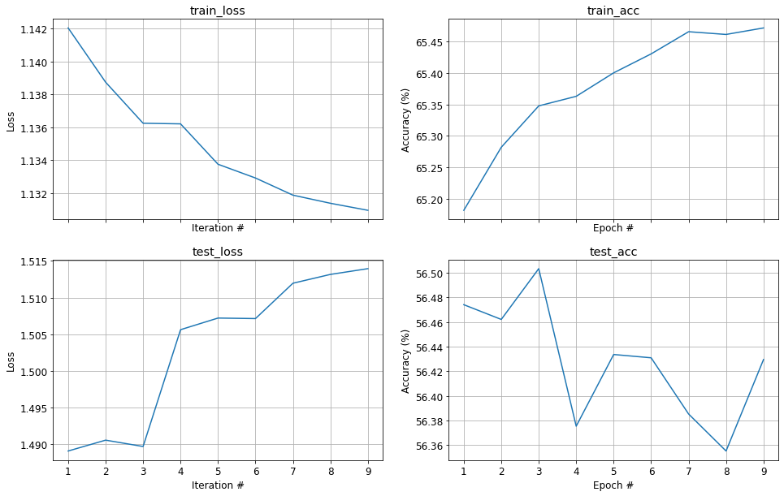

```python
from cs236781.plot import plot_fit

def post_epoch_fn(epoch, train_res, test_res, verbose):
    # Update learning rate
    scheduler.step(test_res.accuracy)
    # Sample from model to show progress
    if verbose:
        start_seq = "ACT I."
        generated_sequence = charnn.generate_from_model(
            model, start_seq, 100, (char_to_idx,idx_to_char), T=0.5
        )
        print(generated_sequence)

# Train, unless final checkpoint is found
checkpoint_file_final = f'{checkpoint_file}_final.pt'
if os.path.isfile(checkpoint_file_final):
    print(f'*** Loading final checkpoint file {checkpoint_file_final} instead of training')
    saved_state = torch.load(checkpoint_file_final, map_location=device)
    model.load_state_dict(saved_state['model_state'])
else:
    try:
        # Print pre-training sampling
        print(charnn.generate_from_model(model, "ACT I.", 100, (char_to_idx,idx_to_char), T=0.5))

        fit_res = trainer.fit(dl_train, dl_test, num_epochs, max_batches=None,
                              post_epoch_fn=post_epoch_fn, early_stopping=early_stopping,
                              checkpoints=checkpoint_file, print_every=1)

        fig, axes = plot_fit(fit_res)
    except KeyboardInterrupt as e:
        print('\n *** Training interrupted by user')
```

### Generating a work of art

Armed with our fully trained model, let's generate the next Hamlet! You should experiment with modifying the sampling temperature and see what happens.

The text you generate should “look” like a Shakespeare play: old-style English words and sentence structure, directions for the actors (like “Exit/Enter”), sections (Act I/Scene III) etc. There will be no coherent plot of course, but it should at least seem like a Shakespearean play when not looking too closely. If this is not what you see, go back, debug and/or and re-train.

**TODO**: Specify the generation parameters in the `part3_generation_params()` function within the `hw3/answers.py` module.

```python
from hw3.answers import part3_generation_params

start_seq, temperature = part3_generation_params()

generated_sequence = charnn.generate_from_model(
    model, start_seq, 10000, (char_to_idx,idx_to_char), T=temperature
)

print(generated_sequence)
```

```
Long time ago I woke from a deep sleep to see the wars or two of the time,
    The noblest of them that did seem to see the wealth of peace,
    The more the lineal shepherd of the morning bear the same and love,
    That did him longer than he then to be of note of strength,
    The bond of the dead of the earth that ever thought the same,
    And then the first day hath some sentence to the prince.

                          Enter CLEOPATRA

  CLOTEN. If I could tell the way to try his father and my son were much detested by any man when I am dead.

SICINIUS:
I would I were a fool, and that my father was not there
    To see a strange intent to seek you to the gates of the court,
    Which I have seen a lady of the world,
    And that the strong souls from his majesty I saw him here,
    Their swifts are dangerous, where they shall be false.

                             Enter TIMON

  SECOND SOLDIER. What wouldst thou stand to the Lear and a service to his mother?
  LEONTES. What can he tell the honour of my brother,
    And love thee well, and I will take the contrary,
    And that the fear is daily gentleman,
    And I myself have learnt thee of a flower, and all the rest,
    And he shall give a thousand times to do them kind of hearts.
    This is the day the son of God and this man laid on the walls of heaven,
    That heaven stopp'd from the world, and there my life is spoke
    To have his soul for traitors to the chamber by the table of a good lady.
  PROTEUS. It is the man when my lord shall advocate the senators of the death.

CORIOLANUS:
I will not stand so much:
The service I am sure you will not.

LADY ANNE:
No, my good lord:
I was at your treason.

MENENIUS:
```

[output cut: 212 more lines]

```
Though it be so, and I will speak to thee.

CORIOLANUS:
Are you so rich in the name of Greece.

BUCKINGHAM:
I do beseech you, sir, I pray thee, fellow,
That ever I live to be to be advis'd to do it, sir, as it did see this deed.

MESSENGER:
It shall be the soul of our conscience and the sea,
That thou dost give me leave to say the truth of it:
I shall be placed to her chamber.

KING RICHAR
```

## Questions

**TODO** Answer the following questions. Write your answers in the appropriate variables in the module `hw3/answers.py`.

```python
from cs236781.answers import display_answer
import hw3.answers
```

### Question 1

Why do we split the corpus into sequences instead of training on the whole text?

```python
display_answer(hw3.answers.part3_q1)
```

Splitting the corpus into sequences improves the training time significantly, training on the whole data set will take too long to train. Moreover training on the whole set can result in vanishing gradients, resulting in non-trainable network, and splitting the set solves that.

### Question 2

How is it possible that the generated text clearly shows memory longer than the sequence length?

```python
display_answer(hw3.answers.part3_q2)
```

Because the generated text includes the history so after some iterations, the generated text will be longer than the sequence length because of the history includes in it.

### Question 3

Why are we not shuffling the order of batches when training?

```python
display_answer(hw3.answers.part3_q3)
```

Because in our problem the order of the text matters, and we rely on it in our predictions. Shuffling the batches will result in non logical sentences and will harm the results.

### Question 4

1. Why do we lower the temperature for sampling (compared to the default of $1.0$)?
2. What happens when the temperature is very high and why?
3. What happens when the temperature is very low and why?

```python
display_answer(hw3.answers.part3_q4)
```

1. With a low temperature, we reduce the chance of low score character to be chosen. We use lower temperatures here to allow the model to pick a character that is based on what the model has already learnt.

2. If the temperature is very high, also the low scored character will get decent probability to be chosen, resulting in big variance in the prediction regardless of the scores.

3. Low temperature will cause in amplifying the probability of the higher scored characters to be chose, resulting in almost deterministic action, predicting the same character every time.